# The $\mathbf{A} \mathbf{B} \mathbf{A}^T$ Pattern: Transforming Covariance

## 3. Properties of $\mathbf{A}\mathbf{B}\mathbf{A}^T$

Important properties:

1. **Symmetry preserved**: If $\mathbf{B}$ is symmetric, so is $\mathbf{A}\mathbf{B}\mathbf{A}^T$
2. **Positive (semi-)definiteness preserved**: If $\mathbf{B}$ is PSD, so is $\mathbf{A}\mathbf{B}\mathbf{A}^T$
3. **Rank**: $\text{rank}(\mathbf{A}\mathbf{B}\mathbf{A}^T) \leq \min(\text{rank}(\mathbf{A}), \text{rank}(\mathbf{B}))$

```python
# Demonstrate properties
np.random.seed(42)

# B is symmetric PSD (a covariance matrix)
temp = np.random.randn(3, 3)
B = temp @ temp.T  # Always PSD

# A is a non-square transformation
A = np.random.randn(2, 3)

# Compute ABA.T
result = A @ B @ A.T

print("Properties of A @ B @ A.T")
print("="*50)
print(f"\nB ({B.shape[0]}×{B.shape[1]}):")
print(B.round(3))
print(f"B is symmetric: {np.allclose(B, B.T)}")
print(f"B eigenvalues (all ≥ 0 for PSD): {np.linalg.eigvalsh(B).round(3)}")

print(f"\nA ({A.shape[0]}×{A.shape[1]}):")
print(A.round(3))

print(f"\nA @ B @ A.T ({result.shape[0]}×{result.shape[1]}):")
print(result.round(3))
print(f"Result is symmetric: {np.allclose(result, result.T)}")
print(f"Result eigenvalues: {np.linalg.eigvalsh(result).round(3)}")
print(f"Result is PSD: {all(np.linalg.eigvalsh(result) >= -1e-10)}")
```

```
Properties of A @ B @ A.T
==================================================

B (3×3):
[[0.685 0.637 0.374]
 [0.637 2.429 2.335]
 [0.374 2.335 3.303]]
B is symmetric: True
B eigenvalues (all ≥ 0 for PSD): [0.283 0.789 5.346]

A (2×3):
[[ 0.543 -0.463 -0.466]
 [ 0.242 -1.913 -1.725]]

A @ B @ A.T (2×2):
[[ 1.938  7.72 ]
 [ 7.72  33.274]]
Result is symmetric: True
Result eigenvalues: [ 0.14  35.072]
Result is PSD: True
```

## 4. Special Cases

| Pattern | Name | Meaning |
| --- | --- | --- |
| $\mathbf{A} \mathbf{A}^T$ | Gram matrix | Covariance when $\mathbf{B} = \mathbf{I}$ |
| $\mathbf{Q} \mathbf{B} \mathbf{Q}^T$ | Similarity transform (orthogonal) | Rotates the covariance |
| $\mathbf{D} \mathbf{B} \mathbf{D}^T$ | Diagonal scaling | Scales variances independently |

```python
# Example: Orthogonal transformation (rotation) preserves eigenvalues
B = np.array([[3, 1], [1, 2]])  # Original covariance

# Rotation matrix (orthogonal)
theta = np.pi/4
Q = np.array([[np.cos(theta), -np.sin(theta)],
              [np.sin(theta), np.cos(theta)]])

# Rotated covariance
B_rotated = Q @ B @ Q.T

print("Rotation Preserves Eigenvalues")
print("="*50)
print(f"\nOriginal B eigenvalues: {np.linalg.eigvalsh(B).round(4)}")
print(f"Rotated Q B Q.T eigenvalues: {np.linalg.eigvalsh(B_rotated).round(4)}")
print(f"\nEigenvalues preserved: {np.allclose(sorted(np.linalg.eigvalsh(B)), sorted(np.linalg.eigvalsh(B_rotated)))}")
```

```
Rotation Preserves Eigenvalues
==================================================

Original B eigenvalues: [1.382 3.618]
Rotated Q B Q.T eigenvalues: [1.382 3.618]

Eigenvalues preserved: True
```

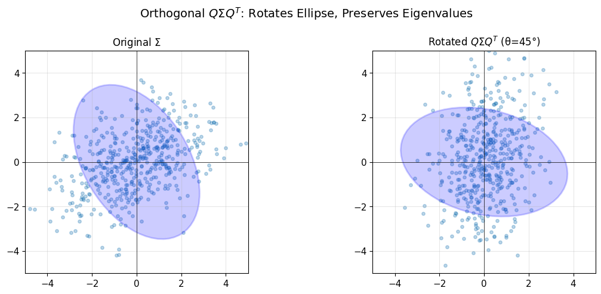

```python
# Visualize rotation of covariance ellipse
fig, axes = plt.subplots(1, 2, figsize=(12, 5))

for ax, cov, title in [(axes[0], B, 'Original $\\Sigma$'),
                        (axes[1], B_rotated, f'Rotated $Q\\Sigma Q^T$ (θ={int(np.degrees(theta))}°)')]:
    # Generate samples
    samples = np.random.multivariate_normal([0, 0], cov, 500)
    ax.scatter(samples[:, 0], samples[:, 1], alpha=0.3, s=15)
    plot_covariance_ellipse(ax, [0, 0], cov, n_std=2,
                           facecolor='blue', alpha=0.2, edgecolor='blue', linewidth=2)
    ax.set_xlim(-5, 5)
    ax.set_ylim(-5, 5)
    ax.set_aspect('equal')
    ax.grid(True, alpha=0.3)
    ax.axhline(y=0, color='black', linewidth=0.5)
    ax.axvline(x=0, color='black', linewidth=0.5)
    ax.set_title(title, fontsize=12)

plt.suptitle('Orthogonal $Q\\Sigma Q^T$: Rotates Ellipse, Preserves Eigenvalues', fontsize=14)
plt.tight_layout()
plt.show()
```

## Key Takeaways

1. **The formula**: If $\mathbf{y} = \mathbf{A}\mathbf{x}$ and $\text{Cov}(\mathbf{x}) = \mathbf{\Sigma}$, then: $$\text{Cov}(\mathbf{y}) = \mathbf{A} \mathbf{\Sigma} \mathbf{A}^T$$
2. **Intuition**: Linear transformations "stretch" covariance structure
   - $\mathbf{A}$ defines the transformation
   - $\mathbf{A}^T$ ensures the result is still a valid covariance (symmetric, PSD)
3. **Applications**:
   - **Sensor fusion**: Combine measurements optimally
   - **Factor analysis**: Few factors → complex correlations
   - **Kalman filter**: Propagate uncertainty through time
4. **Properties preserved**: Symmetry and positive semi-definiteness

**Next**: We'll explore the **Schur complement** — what happens when we condition on part of a multivariate Gaussian.